# M04Guided

Alanna Hazlett

2024-02-17

# Problem 1

Produce a plot of body mass against flipper length for Gentoo penguins. Write the estimated linear regression equation.

```r
result<-lm(body_mass_g~flipper_length_mm,data=Gentoo)
summary(result)
```

```
##
## Call:
## lm(formula = body_mass_g ~ flipper_length_mm, data = Gentoo)
##
## Residuals:
##     Min      1Q  Median      3Q     Max
## -911.18 -235.76  -51.93  170.75 1015.71
##
## Coefficients:
##                    Estimate Std. Error t value Pr(>|t|)
## (Intercept)       -6787.281   1092.552  -6.212 7.65e-09 ***
## flipper_length_mm    54.623      5.028  10.863  < 2e-16 ***
## ---
## Signif. codes:  0 '***' 0.001 '**' 0.01 '*' 0.05 '.' 0.1 ' ' 1
##
## Residual standard error: 360.2 on 121 degrees of freedom
## Multiple R-squared:  0.4937, Adjusted R-squared:  0.4896
## F-statistic:   118 on 1 and 121 DF,  p-value: < 2.2e-16
```

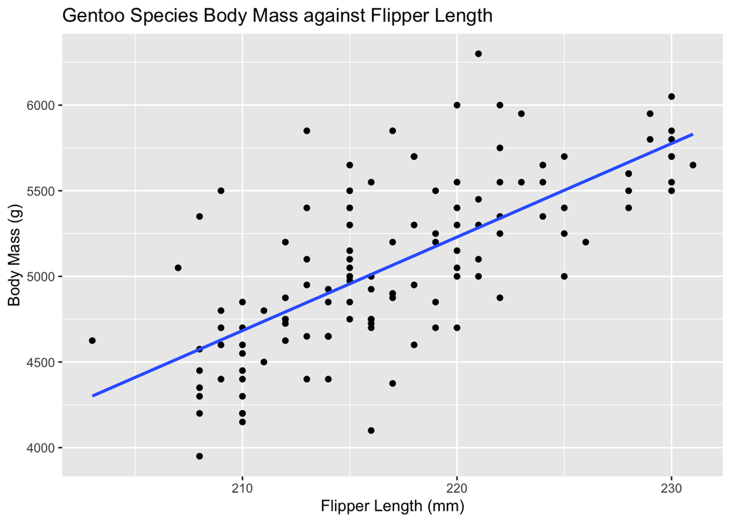

```r
ggplot2::ggplot(Gentoo,aes(x=flipper_length_mm,y=body_mass_g))+
  geom_point()+
  geom_smooth(method="lm",se=FALSE)+
  labs(x="Flipper Length (mm)",y="Body Mass (g)",title="Gentoo Species Body Mass against Flipper Length")
```

The estimated linear regression equation is:
$$\hat y=\hat\beta_{0}+\hat\beta_{1}x$$
$$\hat y = -6787.281 + 54.623x$$

# Problem 2

What is the change in the predicted body mass (in grams) when flipper length increases by 1mm, for Gentoo penguins? Also report the corresponding 95% confidence interval for the change in the predicted body mass (in grams) when flipper length increases by 1mm.  
The predicted body mass increases by 54.623 grams when flipper length increases by 1mm.

```r
confint(result,level=0.95)[2,]
```

```
##    2.5 %   97.5 %
## 44.66777 64.57724
```

# Problem 3

Conduct a hypothesis test to determine whether or not there is a linear association between body mass and flipper length for Gentoo penguins. State the hypotheses, p-value, and conclusion in context.

$$H_{0}: \beta_{1} = 0\\H_{a}: \beta_{1}
\neq 0$$
The p-value is 2e-16, which is smaller than our significance level of 0.05. This means that we reject our null hypothesis of slope = 0 and our data supports the alternative hypothesis that slope does not equal zero. This indicates that there is a linear association between our variables.

# Problem 4

Are your results from parts 2 and 3 consistent? Briefly explain.  
Yes, our hypothesis test indicates that slope does not equal zero. Our confidence interval shows that we have 95% confidence that our slope is within 44.67 and 64.58, and zero is not within this interval, so slope is not equal to zero.

# Problem 5

Estimate the mean body mass (in grams) for Gentoo penguins with flipper lengths of 200mm. Also report the 95% confidence interval for the mean body mass (in grams) for Gentoo penguins with flipper lengths of 200mm
$$\hat y = -6787.281 + 54.623(200)\\
\hat y = 4137.319g$$

```r
newdata<-data.frame(flipper_length_mm = 200)
predict(result,newdata,level=0.95,interval="confidence")
```

```
##       fit      lwr      upr
## 1 4137.22 3954.446 4319.993
```

The confidence interval is from 3954.45g to 4319.99g.

# Problem 6

Report the 95% prediction interval for the body mass (in grams) of a Gentoo penguin with flipper length of 200mm

```r
predict(result,newdata,level=0.95,interval="prediction")
```

```
##       fit      lwr      upr
## 1 4137.22 3401.121 4873.319
```

The prediction interval is from 3401.12g to 4873.32g.

# Problem 7

A researcher hypothesizes that for Gentoo penguins, the predicted body mass increases by more than 50 g for each additional mm in flipper length. Conduct an appropriate hypothesis test. What is the null and alternative hypotheses, test statistic, and conclusion?
$$H_{0}: \beta_{1} = 50\\H_{a}: \beta_{1}
> 50$$
The test statistic is:
$$t
= \frac {\hat \beta_{1} - 50} {se(\hat \beta_{1})}$$
$$t = \frac {54.623 - 50}{5.028} =
0.91945$$

```r
qt(0.95,121)
```

```
## [1] 1.657544
```

Our test statistic is less than our critical value, so we fail to reject the null hypothesis.